# A zoom into NAO-AO transition using presence/absence data

Lucia Campese

June 2020

### Aim

The aim is to apply the simplex approach proposed by in Podani et al. (2011, 2018) to our presence/absence data.

The simplex is built using three coefficients:

1. Jaccard coefficient of similarity, i.e. shared species (SJac = $\frac{a}{n}$)
2. Relativized richness difference (Drel = $\frac{|b - c|}{n}$)
3. Relativized species replacement (Rrel = $\frac{2min(b,c)}{n}$)

where **a** is the number of species present in both sites being compared, **b** is the number of species present only in the first one and **c** is the number of species present only in the second site, so that a + b + c = n.

The three coefficients are calculated for all the possible pairs of sites in a presence/absence data matrix, providing a diagram that depicts data structure in terms of similarity, relativized richness difference and relativized species replacement, each corresponding to a corner of the triangle.

This traingle plot is referred to as the SDR-simplex, as it is the simultaneous display of relationships as revealed by measures SJac, Drel and Rrel.

How to read the plot: In general, the proximity of a point to the vertices is proportional to the respective coefficient values.

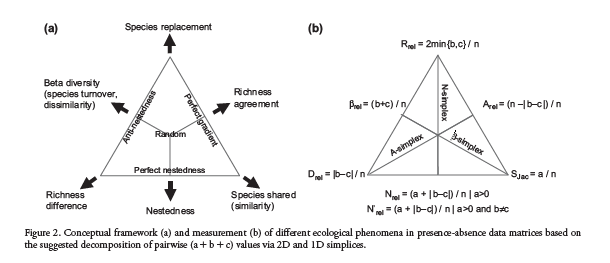

SDR simplex

## Zoom in the Transition from Atlantic to Arctic Ocean

### Dataset

##### Omic data: metaB, metaG, metaT

##### Taxon: Diatoms

##### Depth: Surface

##### Size fraction: 20-180 um

##### Geographic scale: North Atlantic Ocean, Arctic Ocean

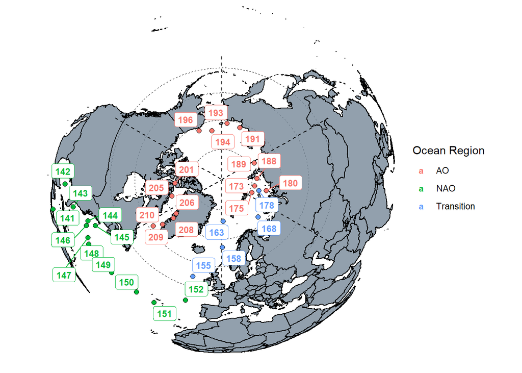

```r
library(tidyverse)
library(ggplot2)
library(maps)
library(ggrepel)


dat_samp <- read.delim("~/PhD/TARA_Data/dat_samp.txt")

#upload maps
world_map <- map_data("world")
p <- ggplot() + coord_fixed()
base_world3 <- p + geom_polygon(data=world_map,aes(x=long, y=lat,group=group),colour="gray80",size=0.2, fill="gray80")+
  theme_bw() + coord_fixed()

NAO <- as.character(c(141:152))
Transition <- as.character(c(155,158,163,168,178))
AO <- as.character(c(173,175,178:210))

NAOAO_points <- dat_samp %>%
  mutate(Station.label = substr(Station.label, 6, 8)) %>%
  filter(Station.label %in% c(NAO, Transition, AO)) %>%
  group_by(Station.label) %>%
  summarise(Latitude = mean(Latitude), Longitude = mean(Longitude)) %>%
  ungroup() %>%
  mutate(`Ocean Region` = case_when(Station.label %in% NAO ~ "NAO",
                                    Station.label %in% Transition ~ "Transition",
                                    Station.label %in% AO ~ "AO"))

#Define the x axes required
x_lines <- seq(-120,180, by = 60)

ggplot() +
  geom_polygon(data = world_map, aes(x = long, y = lat, group = group), fill = "lightslategrey", colour = "black", alpha = 0.8)+
  #Convert to polar coordinates
  coord_map("ortho", orientation = c(90, 0, 0)) +
  scale_y_continuous(breaks = seq(50, 90, by = 10), labels = NULL) +
  scale_x_continuous(breaks = NULL) +
  xlab("") +
  ylab("") +
  geom_segment(aes(y = 45, yend = 90, x = x_lines, xend = x_lines), linetype = "dashed") +
  geom_point(data=NAOAO_points, aes(x=Longitude,y=Latitude, fill = `Ocean Region`),color="black",shape=21,cex=2) +
  geom_label_repel(data=NAOAO_points, aes(x=Longitude,y=Latitude, col= `Ocean Region`),
                   label=NAOAO_points$Station.label,
                   fontface=2, size = 3) +
   theme(panel.background = element_blank(),
        panel.grid.major = element_line(size = 0.25, linetype = 'dashed',
                                        colour = "black"),
        axis.ticks=element_blank())
```

##### metaB

```r
library(tidyverse)
library(vegan)
library(ggtern)
library(data.table)

thsh <- 9

load("C:/Users/Userszn/Documents/PhD/TARA_Data/metaB/diatoms/metab_diatoms_20171106.RData")
dat_samp <- read.delim("~/PhD/TARA_Data/dat_samp.txt")


#filter datsamp
NAOAO_20180_SRF <- dat_samp %>%
  mutate(Station.label = substr(Station.label, 6, 8),
         Station.label = as.numeric(Station.label)) %>%
  filter(Station.label %in% c(141:210),
         Depth == "SRF",
         Fraction.size == "20-180")


#take reads only in the stations, depths and fractions of interest
metab_NAOAO_SRF <- metab_diatoms_20171106 %>%
  pivot_longer(BV9_1:TV9_99) %>%
  rename(Sample.id = name) %>%
  inner_join(NAOAO_20180_SRF, by="Sample.id") %>%
  select(cid, Station.label, value) %>%
  mutate(value = ifelse(value > 0, 1, 0)) %>%
  filter(value !=0) %>%
  add_count(cid, name = "Occurrences") %>%
  rename("Type/OTU" = cid, Station = Station.label) %>%
  filter(Occurrences > thsh)

tara_pabs <- metab_NAOAO_SRF %>%
  select(`Type/OTU`, Station)

comn <- tara_pabs %>%
  group_by(Station) %>%
  summarise(data = list(`Type/OTU`))

pairnames <- expand_grid(S1 = as.character(comn$Station), S2 = as.character(comn$Station))
data      <- expand_grid(D1 = comn$data, D2 = comn$data)


temp_vector <- NAOAO_20180_SRF %>%
  rename(Station = Station.label) %>%
  select(Station, Temperature) %>%
  distinct %>%
  arrange(Station) %>%
  group_by(Station) %>%
  summarise(Temperature = mean(Temperature)) %>%
  column_to_rownames("Station")


###

rapa_metaB_NAOAO <- bind_cols(pairnames, data) %>%
  mutate(int = map2(D1, D2, ~intersect(.x, .y)),
         a = map_int(int, ~length(.x)),
         b = map2_int(D1, int, ~length(setdiff(.x, .y))),
         c = map2_int(D2, int, ~length(setdiff(.x, .y))), n = a + b + c) %>%
  mutate(Sjac = a / n,
         Drel = abs(b - c) / n,
         Rrel = 2 * pmin(b, c) / n) %>%
  mutate(T1 = temp_vector[S1,]) %>%
  mutate(T2 = temp_vector[S2,]) %>%
  mutate(`Delta temperature` = abs(T1 - T2)) %>%
  mutate(Richness = map_int(D1, ~length(.x)))
```

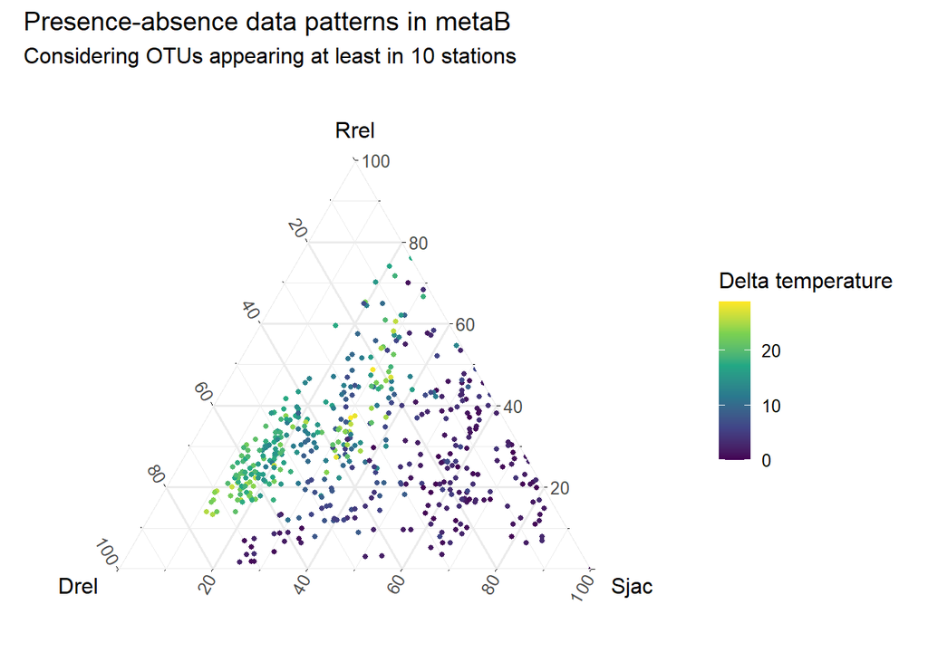

```r
ggtern(data = rapa_metaB_NAOAO, aes(Drel, Rrel, Sjac)) +
  geom_point(size = 1, aes(col = `Delta temperature`)) +
  scale_color_viridis_c() +
  theme_minimal() +
  labs(title = "Presence-absence data patterns in metaB",
       subtitle = paste("Considering OTUs appearing at least in",
                        thsh + 1,
                        "stations"))
```

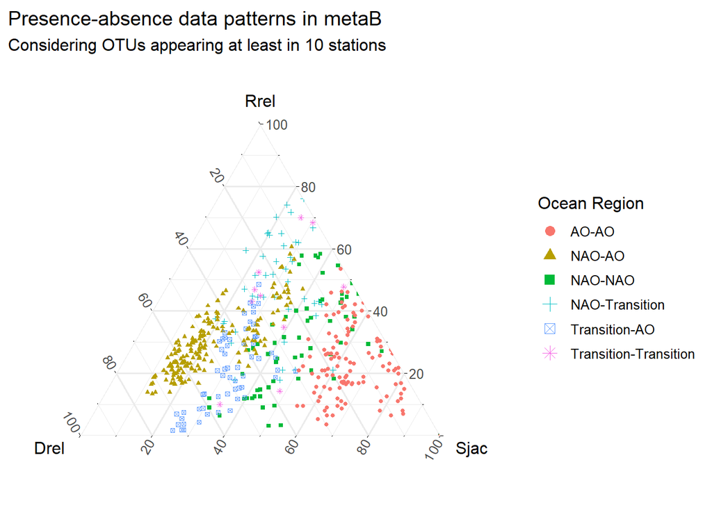

```r
NAO <- as.character(c(141:152))
Transition <- as.character(c(155,158,163,168,178))
AO <- as.character(c(173,175,178:210))

rapa_metaB_NAOAO2 <- rapa_metaB_NAOAO %>%
  mutate(`Ocean Region` = case_when(S1 %in% NAO & S2 %in% NAO ~ "NAO-NAO",
                                    S1 %in% Transition & S2 %in% Transition ~ "Transition-Transition",
                                    S1 %in% AO & S2 %in% AO  ~ "AO-AO",
                                    (S1 %in% NAO & S2 %in% AO) | (S1 %in% AO & S2 %in% NAO) ~ "NAO-AO",
                                    (S1 %in% NAO & S2 %in% Transition) | (S1 %in% Transition & S2 %in% NAO) ~ "NAO-Transition",
                                    (S1 %in% Transition & S2 %in% AO) | (S1 %in% AO & S2 %in% Transition) ~ "Transition-AO"))


ggtern(data = rapa_metaB_NAOAO2, aes(Drel, Rrel, Sjac)) +
  geom_point(size = 1, aes(col = `Ocean Region`, shape = `Ocean Region`)) +
  guides(colour = guide_legend(override.aes = list(size=3))) +
  theme_minimal() +
  labs(title = "Presence-absence data patterns in metaB",
       subtitle = paste("Considering OTUs appearing at least in",
                        thsh + 1,
                        "stations"))
```

##### metaG

```r
load("~/PhD/script/Podani/rapa_metag.RData")

Polar <- as.character(c(84:89, 158:210))
Non_Polar <- as.character(c(7:83, 90:155))

rapa_metag_all <- rapa_metag %>%
  mutate(T1 = temp_vector[S1, ]) %>%
  mutate(T2 = temp_vector[S2, ]) %>%
  mutate(`Delta temperature` = abs(T1 - T2)) %>%
  mutate(`Marine Biome` = case_when(S1 %in% Polar & S2 %in% Polar ~ "Polar",
                                    (S1 %in% Polar & S2 %in% Non_Polar |
                                       S1 %in% Non_Polar & S2 %in% Polar) ~ "Polar-Non Polar",
                                    S1 %in% Non_Polar & S2 %in% Non_Polar  ~ "Non Polar"))

###NAOAO
NAO <- as.character(c(141:152))
Transition <- as.character(c(155,158,163,168,178))
AO <- as.character(c(173,175,178:210))

rapa_metag_NAOAO <- rapa_metag_all %>%
  filter(S1 %in% c(NAO, Transition, AO),
         S2 %in% c(NAO, Transition, AO))


rapa_metag_NAOAO2 <- rapa_metag_NAOAO %>%
  mutate(`Ocean Region` = case_when(S1 %in% NAO & S2 %in% NAO ~ "NAO-NAO",
                                    S1 %in% Transition & S2 %in% Transition ~ "Transition-Transition",
                                    S1 %in% AO & S2 %in% AO  ~ "AO-AO",
                                    (S1 %in% NAO & S2 %in% AO) | (S1 %in% AO & S2 %in% NAO) ~ "NAO-AO",
                                    (S1 %in% NAO & S2 %in% Transition) | (S1 %in% Transition & S2 %in% NAO) ~ "NAO-Transition",
                                    (S1 %in% Transition & S2 %in% AO) | (S1 %in% AO & S2 %in% Transition) ~ "Transition-AO"))
```

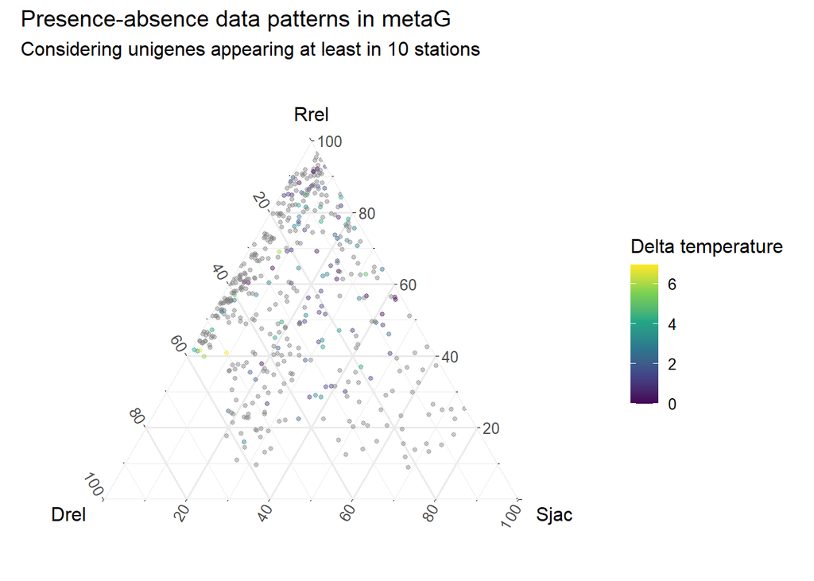

```r
ggtern(data = rapa_metag_NAOAO2, aes(Drel, Rrel, Sjac)) +
  geom_point(size = 1, alpha = 0.25, aes(col = `Delta temperature`)) +
  scale_color_viridis_c() +
  theme_minimal() +
  labs(title = "Presence-absence data patterns in metaG",
       subtitle = paste("Considering unigenes appearing at least in",
                        thsh + 1,
                        "stations"))
```

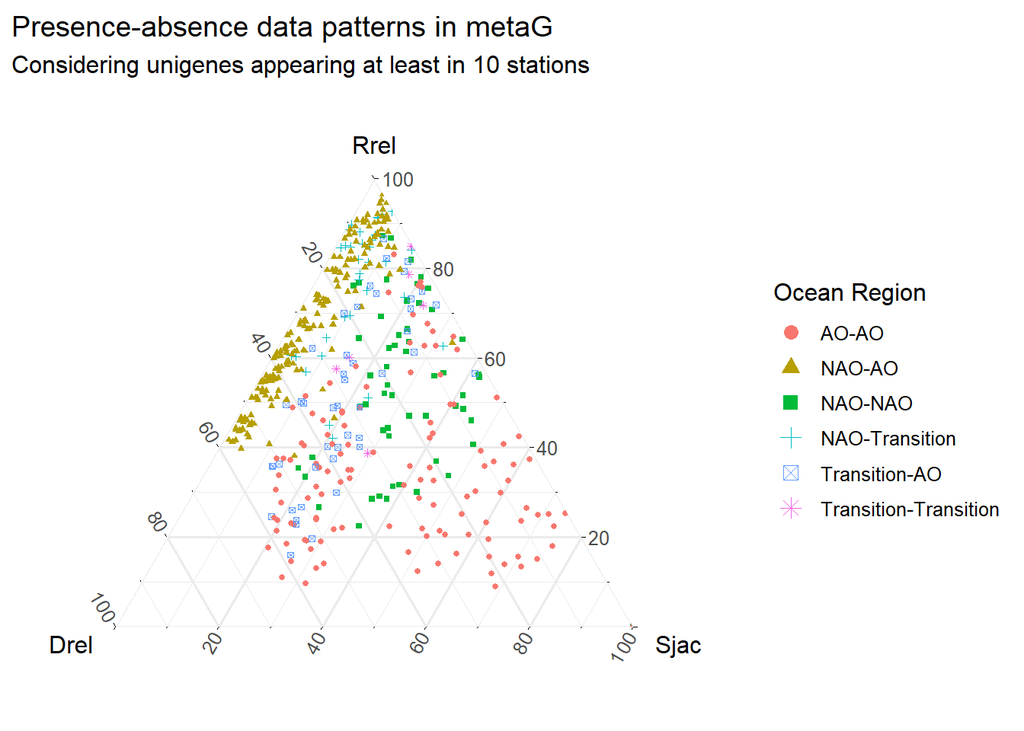

```r
ggtern(data = rapa_metag_NAOAO2, aes(Drel, Rrel, Sjac)) +
  geom_point(size = 1, aes(col = `Ocean Region`, shape = `Ocean Region`)) +
  guides(colour = guide_legend(override.aes = list(size=3))) +
  theme_minimal() +
  labs(title = "Presence-absence data patterns in metaG",
       subtitle = paste("Considering unigenes appearing at least in",
                        thsh + 1,
                        "stations"))
```

##### metaT

```r
load("~/PhD/script/Podani/rapa_metat.RData")

Polar <- as.character(c(84:89, 158:210))
Non_Polar <- as.character(c(7:83, 90:155))

rapa_metat_all <- rapa_metat %>%
  mutate(T1 = temp_vector[S1, ]) %>%
  mutate(T2 = temp_vector[S2, ]) %>%
  mutate(`Delta temperature` = abs(T1 - T2)) %>%
  mutate(`Marine Biome` = case_when(S1 %in% Polar & S2 %in% Polar ~ "Polar",
                                    (S1 %in% Polar & S2 %in% Non_Polar |
                                       S1 %in% Non_Polar & S2 %in% Polar) ~ "Polar-Non Polar",
                                    S1 %in% Non_Polar & S2 %in% Non_Polar  ~ "Non Polar"))

###NAOAO
NAO <- as.character(c(141:152))
Transition <- as.character(c(155,158,163,168,178))
AO <- as.character(c(173,175,178:210))

rapa_metat_NAOAO <- rapa_metat_all %>%
  filter(S1 %in% c(NAO, Transition, AO),
         S2 %in% c(NAO, Transition, AO))


rapa_metat_NAOAO2 <- rapa_metat_NAOAO %>%
  mutate(`Ocean Region` = case_when(S1 %in% NAO & S2 %in% NAO ~ "NAO-NAO",
                                    S1 %in% Transition & S2 %in% Transition ~ "Transition-Transition",
                                    S1 %in% AO & S2 %in% AO  ~ "AO-AO",
                                    (S1 %in% NAO & S2 %in% AO) | (S1 %in% AO & S2 %in% NAO) ~ "NAO-AO",
                                    (S1 %in% NAO & S2 %in% Transition) | (S1 %in% Transition & S2 %in% NAO) ~ "NAO-Transition",
                                    (S1 %in% Transition & S2 %in% AO) | (S1 %in% AO & S2 %in% Transition) ~ "Transition-AO"))
```

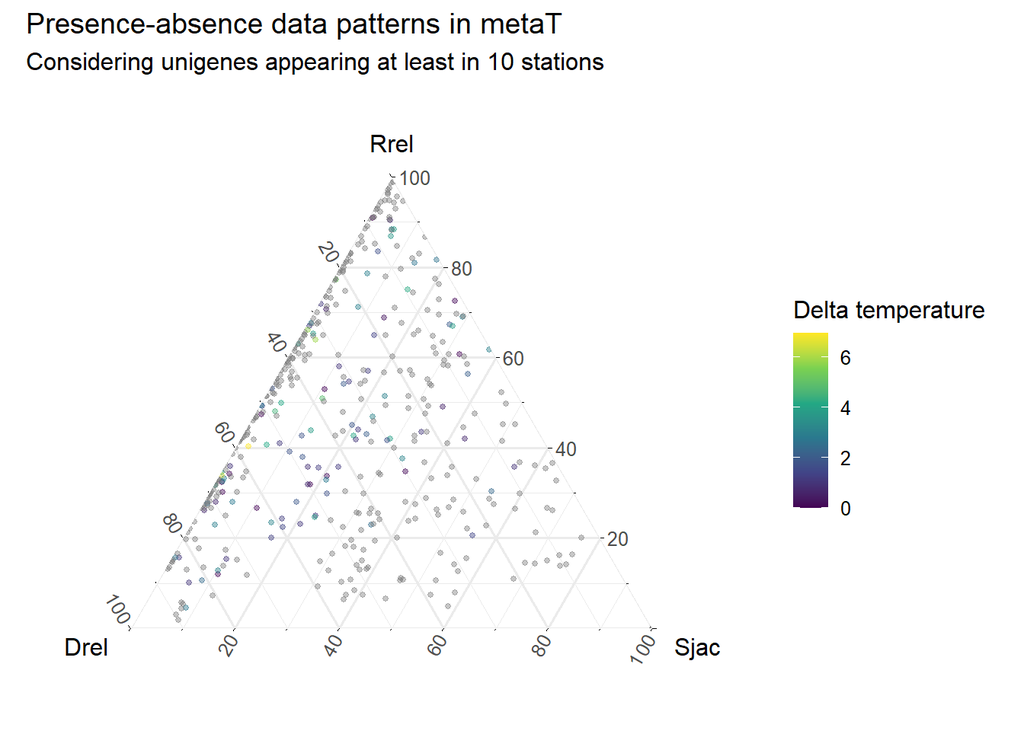

```r
ggtern(data = rapa_metat_NAOAO2, aes(Drel, Rrel, Sjac)) +
  geom_point(size = 1, alpha = 0.25, aes(col = `Delta temperature`)) +
  scale_color_viridis_c() +
  theme_minimal() +
  labs(title = "Presence-absence data patterns in metaT",
       subtitle = paste("Considering unigenes appearing at least in",
                        thsh + 1,
                        "stations"))
```

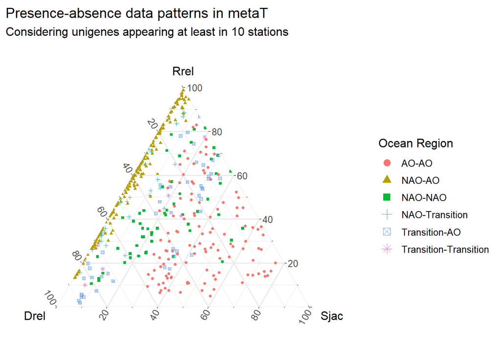

```r
ggtern(data = rapa_metat_NAOAO2, aes(Drel, Rrel, Sjac)) +
  geom_point(size = 1, aes(col = `Ocean Region`, shape = `Ocean Region`)) +
  guides(colour = guide_legend(override.aes = list(size=3))) +
  theme_minimal() +
  labs(title = "Presence-absence data patterns in metaT",
       subtitle = paste("Considering unigenes appearing at least in",
                        thsh + 1,
                        "stations"))
```